# Optimal Treatment Analysis

## Outcome Variable

**Outcome Variable:** ever_stunted

## Predictor Variables

**Intervention Variable:** fage

**Adjustment Set:**

- arm
- W_mage
- meducyrs
- feducyrs
- W_mhtcm
- W_mwtkg
- W_mbmi
- W_fhtcm
- single
- brthmon
- delta_W_mage
- delta_meducyrs
- delta_feducyrs
- delta_W_mhtcm
- delta_W_mwtkg
- delta_W_mbmi
- delta_W_fhtcm
- delta_single
- delta_brthmon

## Stratifying Variables

The analysis was stratified on these variable(s):

- agecat
- studyid
- country

## Data Summary

| agecat | studyid | country | fage | ever_stunted | n_cell | n |
| --- | --- | --- | --- | --- | --- | --- |
| 0-24 months | ki0047075b-MAL-ED | BANGLADESH | >=38 | 0 | 28 | 151 |
| 0-24 months | ki0047075b-MAL-ED | BANGLADESH | >=38 | 1 | 41 | 151 |
| 0-24 months | ki0047075b-MAL-ED | BANGLADESH | <32 | 0 | 7 | 151 |
| 0-24 months | ki0047075b-MAL-ED | BANGLADESH | <32 | 1 | 23 | 151 |
| 0-24 months | ki0047075b-MAL-ED | BANGLADESH | [32-38) | 0 | 23 | 151 |
| 0-24 months | ki0047075b-MAL-ED | BANGLADESH | [32-38) | 1 | 29 | 151 |
| 0-24 months | ki0047075b-MAL-ED | BRAZIL | >=38 | 0 | 22 | 79 |
| 0-24 months | ki0047075b-MAL-ED | BRAZIL | >=38 | 1 | 8 | 79 |
| 0-24 months | ki0047075b-MAL-ED | BRAZIL | <32 | 0 | 10 | 79 |
| 0-24 months | ki0047075b-MAL-ED | BRAZIL | <32 | 1 | 8 | 79 |
| 0-24 months | ki0047075b-MAL-ED | BRAZIL | [32-38) | 0 | 26 | 79 |
| 0-24 months | ki0047075b-MAL-ED | BRAZIL | [32-38) | 1 | 5 | 79 |
| 0-24 months | ki0047075b-MAL-ED | INDIA | >=38 | 0 | 16 | 161 |
| 0-24 months | ki0047075b-MAL-ED | INDIA | >=38 | 1 | 20 | 161 |
| 0-24 months | ki0047075b-MAL-ED | INDIA | <32 | 0 | 19 | 161 |
| 0-24 months | ki0047075b-MAL-ED | INDIA | <32 | 1 | 34 | 161 |
| 0-24 months | ki0047075b-MAL-ED | INDIA | [32-38) | 0 | 25 | 161 |
| 0-24 months | ki0047075b-MAL-ED | INDIA | [32-38) | 1 | 47 | 161 |
| 0-24 months | ki0047075b-MAL-ED | NEPAL | >=38 | 0 | 12 | 79 |
| 0-24 months | ki0047075b-MAL-ED | NEPAL | >=38 | 1 | 5 | 79 |
| 0-24 months | ki0047075b-MAL-ED | NEPAL | <32 | 0 | 9 | 79 |
| 0-24 months | ki0047075b-MAL-ED | NEPAL | <32 | 1 | 6 | 79 |
| 0-24 months | ki0047075b-MAL-ED | NEPAL | [32-38) | 0 | 28 | 79 |
| 0-24 months | ki0047075b-MAL-ED | NEPAL | [32-38) | 1 | 19 | 79 |
| 0-24 months | ki0047075b-MAL-ED | PERU | >=38 | 0 | 10 | 85 |
| 0-24 months | ki0047075b-MAL-ED | PERU | >=38 | 1 | 17 | 85 |
| 0-24 months | ki0047075b-MAL-ED | PERU | <32 | 0 | 8 | 85 |
| 0-24 months | ki0047075b-MAL-ED | PERU | <32 | 1 | 21 | 85 |
| 0-24 months | ki0047075b-MAL-ED | PERU | [32-38) | 0 | 7 | 85 |
| 0-24 months | ki0047075b-MAL-ED | PERU | [32-38) | 1 | 22 | 85 |

[output cut: 204 more lines]

The following strata were considered:

- agecat: 0-24 months, studyid: ki0047075b-MAL-ED, country: BANGLADESH
- agecat: 0-24 months, studyid: ki0047075b-MAL-ED, country: BRAZIL
- agecat: 0-24 months, studyid: ki0047075b-MAL-ED, country: INDIA
- agecat: 0-24 months, studyid: ki0047075b-MAL-ED, country: NEPAL
- agecat: 0-24 months, studyid: ki0047075b-MAL-ED, country: PERU
- agecat: 0-24 months, studyid: ki0047075b-MAL-ED, country: SOUTH AFRICA
- agecat: 0-24 months, studyid: ki0047075b-MAL-ED, country: TANZANIA, UNITED REPUBLIC OF
- agecat: 0-24 months, studyid: ki1000304b-SAS-CompFeed, country: INDIA
- agecat: 0-24 months, studyid: ki1000304b-SAS-FoodSuppl, country: INDIA
- agecat: 0-24 months, studyid: ki1119695-PROBIT, country: BELARUS
- agecat: 0-24 months, studyid: ki1135781-COHORTS, country: GUATEMALA
- agecat: 0-24 months, studyid: ki1135781-COHORTS, country: PHILIPPINES
- agecat: 0-24 months, studyid: ki1148112-LCNI-5, country: MALAWI
- agecat: 0-6 months, studyid: ki0047075b-MAL-ED, country: BANGLADESH
- agecat: 0-6 months, studyid: ki0047075b-MAL-ED, country: BRAZIL
- agecat: 0-6 months, studyid: ki0047075b-MAL-ED, country: INDIA
- agecat: 0-6 months, studyid: ki0047075b-MAL-ED, country: NEPAL
- agecat: 0-6 months, studyid: ki0047075b-MAL-ED, country: PERU
- agecat: 0-6 months, studyid: ki0047075b-MAL-ED, country: SOUTH AFRICA
- agecat: 0-6 months, studyid: ki0047075b-MAL-ED, country: TANZANIA, UNITED REPUBLIC OF
- agecat: 0-6 months, studyid: ki1000304b-SAS-CompFeed, country: INDIA
- agecat: 0-6 months, studyid: ki1000304b-SAS-FoodSuppl, country: INDIA
- agecat: 0-6 months, studyid: ki1119695-PROBIT, country: BELARUS
- agecat: 0-6 months, studyid: ki1135781-COHORTS, country: GUATEMALA
- agecat: 0-6 months, studyid: ki1135781-COHORTS, country: PHILIPPINES
- agecat: 0-6 months, studyid: ki1148112-LCNI-5, country: MALAWI
- agecat: 6-24 months, studyid: ki0047075b-MAL-ED, country: BANGLADESH
- agecat: 6-24 months, studyid: ki0047075b-MAL-ED, country: BRAZIL
- agecat: 6-24 months, studyid: ki0047075b-MAL-ED, country: INDIA
- agecat: 6-24 months, studyid: ki0047075b-MAL-ED, country: NEPAL
- agecat: 6-24 months, studyid: ki0047075b-MAL-ED, country: PERU
- agecat: 6-24 months, studyid: ki0047075b-MAL-ED, country: SOUTH AFRICA
- agecat: 6-24 months, studyid: ki0047075b-MAL-ED, country: TANZANIA, UNITED REPUBLIC OF
- agecat: 6-24 months, studyid: ki1000304b-SAS-CompFeed, country: INDIA
- agecat: 6-24 months, studyid: ki1000304b-SAS-FoodSuppl, country: INDIA
- agecat: 6-24 months, studyid: ki1119695-PROBIT, country: BELARUS
- agecat: 6-24 months, studyid: ki1135781-COHORTS, country: GUATEMALA
- agecat: 6-24 months, studyid: ki1135781-COHORTS, country: PHILIPPINES
- agecat: 6-24 months, studyid: ki1148112-LCNI-5, country: MALAWI

### Dropped Strata

Some strata were dropped due to rare outcomes:

- agecat: 0-24 months, studyid: ki0047075b-MAL-ED, country: SOUTH AFRICA
- agecat: 0-24 months, studyid: ki0047075b-MAL-ED, country: TANZANIA, UNITED REPUBLIC OF
- agecat: 0-6 months, studyid: ki0047075b-MAL-ED, country: BRAZIL
- agecat: 0-6 months, studyid: ki0047075b-MAL-ED, country: NEPAL
- agecat: 0-6 months, studyid: ki0047075b-MAL-ED, country: SOUTH AFRICA
- agecat: 0-6 months, studyid: ki1148112-LCNI-5, country: MALAWI
- agecat: 6-24 months, studyid: ki0047075b-MAL-ED, country: BRAZIL
- agecat: 6-24 months, studyid: ki0047075b-MAL-ED, country: NEPAL
- agecat: 6-24 months, studyid: ki0047075b-MAL-ED, country: PERU
- agecat: 6-24 months, studyid: ki0047075b-MAL-ED, country: SOUTH AFRICA
- agecat: 6-24 months, studyid: ki0047075b-MAL-ED, country: TANZANIA, UNITED REPUBLIC OF

## Methods Detail

We’re interested in the causal parameters $E[Y_a]$ for all values of $a \in \mathcal{A}$. These parameters represent the mean outcome if, possibly contrary to fact, we intervened to set all units to have $A=a$. Under the randomization and positivity assumptions, these are identified by the statistical parameters $\psi_a=E_W[E_{Y|A,W}(Y|A=a,W)]$. In addition, we’re interested in the mean of $Y$, $E[Y]$ under no intervention (the observed mean). We will estimate these parameters by using SuperLearner to fit the relevant likelihood factors – $E_{Y|A,W}(Y|A=a,W)$ and $p(A=a|W)$, and then updating our likelihood fit using a joint TMLE.

For unadjusted analyses ($W=\{\}$), initial likelihoods were estimated using Lrnr_glm to estimate the simple $E(Y|A)$ and Lrnr_mean to estimate $p(A)$. For adjusted analyses, a small library containing Lrnr_glmnet, Lrnr_xgboost, and Lrnr_mean was used.

# Results Detail

## Results Plots

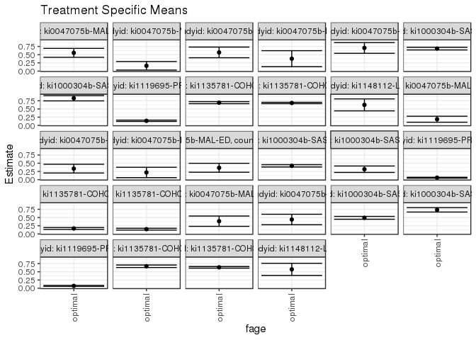

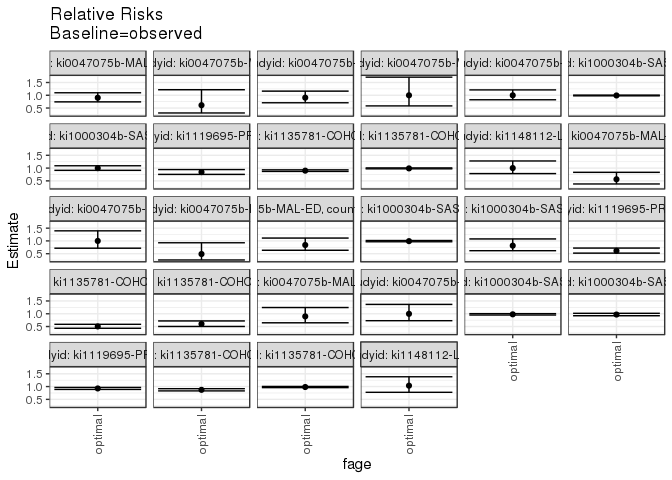

## Results Table

### Parameter: TSM

| agecat | studyid | country | intervention_level | baseline_level | estimate | ci_lower | ci_upper |
| --- | --- | --- | --- | --- | --- | --- | --- |
| 0-24 months | ki0047075b-MAL-ED | BANGLADESH | optimal | NA | 0.5555608 | 0.4201194 | 0.6910022 |
| 0-24 months | ki0047075b-MAL-ED | BRAZIL | optimal | NA | 0.1618581 | 0.0315583 | 0.2921579 |
| 0-24 months | ki0047075b-MAL-ED | INDIA | optimal | NA | 0.5684618 | 0.4059316 | 0.7309920 |
| 0-24 months | ki0047075b-MAL-ED | NEPAL | optimal | NA | 0.3775569 | 0.1343197 | 0.6207942 |
| 0-24 months | ki0047075b-MAL-ED | PERU | optimal | NA | 0.7049190 | 0.5417775 | 0.8680605 |
| 0-24 months | ki1000304b-SAS-CompFeed | INDIA | optimal | NA | 0.6843495 | 0.6436119 | 0.7250871 |
| 0-24 months | ki1000304b-SAS-FoodSuppl | INDIA | optimal | NA | 0.8258780 | 0.7454541 | 0.9063019 |
| 0-24 months | ki1119695-PROBIT | BELARUS | optimal | NA | 0.1396835 | 0.1193525 | 0.1600145 |
| 0-24 months | ki1135781-COHORTS | GUATEMALA | optimal | NA | 0.6908994 | 0.6595475 | 0.7222513 |
| 0-24 months | ki1135781-COHORTS | PHILIPPINES | optimal | NA | 0.6814076 | 0.6612607 | 0.7015545 |
| 0-24 months | ki1148112-LCNI-5 | MALAWI | optimal | NA | 0.6233480 | 0.4413083 | 0.8053877 |
| 0-6 months | ki0047075b-MAL-ED | BANGLADESH | optimal | NA | 0.1868594 | 0.0958094 | 0.2779094 |
| 0-6 months | ki0047075b-MAL-ED | INDIA | optimal | NA | 0.3353368 | 0.2024383 | 0.4682354 |
| 0-6 months | ki0047075b-MAL-ED | PERU | optimal | NA | 0.2188803 | 0.0611312 | 0.3766295 |
| 0-6 months | ki0047075b-MAL-ED | TANZANIA, UNITED REPUBLIC OF | optimal | NA | 0.3614897 | 0.2255018 | 0.4974777 |
| 0-6 months | ki1000304b-SAS-CompFeed | INDIA | optimal | NA | 0.4204357 | 0.3857765 | 0.4550948 |
| 0-6 months | ki1000304b-SAS-FoodSuppl | INDIA | optimal | NA | 0.3172348 | 0.2190823 | 0.4153872 |
| 0-6 months | ki1119695-PROBIT | BELARUS | optimal | NA | 0.0602663 | 0.0469506 | 0.0735820 |
| 0-6 months | ki1135781-COHORTS | GUATEMALA | optimal | NA | 0.1661536 | 0.1373222 | 0.1949850 |
| 0-6 months | ki1135781-COHORTS | PHILIPPINES | optimal | NA | 0.1450187 | 0.1174022 | 0.1726352 |
| 6-24 months | ki0047075b-MAL-ED | BANGLADESH | optimal | NA | 0.3877344 | 0.2306748 | 0.5447939 |
| 6-24 months | ki0047075b-MAL-ED | INDIA | optimal | NA | 0.4395041 | 0.2808132 | 0.5981951 |
| 6-24 months | ki1000304b-SAS-CompFeed | INDIA | optimal | NA | 0.4904218 | 0.4468931 | 0.5339504 |
| 6-24 months | ki1000304b-SAS-FoodSuppl | INDIA | optimal | NA | 0.7339033 | 0.6662893 | 0.8015173 |
| 6-24 months | ki1119695-PROBIT | BELARUS | optimal | NA | 0.0705664 | 0.0571388 | 0.0839940 |
| 6-24 months | ki1135781-COHORTS | GUATEMALA | optimal | NA | 0.6686761 | 0.6310654 | 0.7062868 |
| 6-24 months | ki1135781-COHORTS | PHILIPPINES | optimal | NA | 0.6359228 | 0.6116830 | 0.6601627 |
| 6-24 months | ki1148112-LCNI-5 | MALAWI | optimal | NA | 0.5735813 | 0.3886658 | 0.7584968 |

### Parameter: E(Y)

| agecat | studyid | country | intervention_level | baseline_level | estimate | ci_lower | ci_upper |
| --- | --- | --- | --- | --- | --- | --- | --- |
| 0-24 months | ki0047075b-MAL-ED | BANGLADESH | observed | NA | 0.6156652 | 0.5378291 | 0.6935013 |
| 0-24 months | ki0047075b-MAL-ED | BRAZIL | observed | NA | 0.2649339 | 0.1668953 | 0.3629726 |
| 0-24 months | ki0047075b-MAL-ED | INDIA | observed | NA | 0.6274921 | 0.5525720 | 0.7024123 |
| 0-24 months | ki0047075b-MAL-ED | NEPAL | observed | NA | 0.3782954 | 0.2705913 | 0.4859996 |
| 0-24 months | ki0047075b-MAL-ED | PERU | observed | NA | 0.7062746 | 0.6088351 | 0.8037142 |
| 0-24 months | ki1000304b-SAS-CompFeed | INDIA | observed | NA | 0.6897241 | 0.6494193 | 0.7300290 |
| 0-24 months | ki1000304b-SAS-FoodSuppl | INDIA | observed | NA | 0.8278729 | 0.7916312 | 0.8641145 |
| 0-24 months | ki1119695-PROBIT | BELARUS | observed | NA | 0.1657189 | 0.1468993 | 0.1845385 |
| 0-24 months | ki1135781-COHORTS | GUATEMALA | observed | NA | 0.7679233 | 0.7448419 | 0.7910046 |
| 0-24 months | ki1135781-COHORTS | PHILIPPINES | observed | NA | 0.6894345 | 0.6727391 | 0.7061300 |
| 0-24 months | ki1148112-LCNI-5 | MALAWI | observed | NA | 0.6224215 | 0.5297066 | 0.7151364 |
| 0-6 months | ki0047075b-MAL-ED | BANGLADESH | observed | NA | 0.3322222 | 0.2572977 | 0.4071466 |
| 0-6 months | ki0047075b-MAL-ED | INDIA | observed | NA | 0.3355505 | 0.2623943 | 0.4087067 |
| 0-6 months | ki0047075b-MAL-ED | PERU | observed | NA | 0.4495006 | 0.3431768 | 0.5558243 |
| 0-6 months | ki0047075b-MAL-ED | TANZANIA, UNITED REPUBLIC OF | observed | NA | 0.4304167 | 0.3328948 | 0.5279386 |
| 0-6 months | ki1000304b-SAS-CompFeed | INDIA | observed | NA | 0.4241036 | 0.3960523 | 0.4521549 |
| 0-6 months | ki1000304b-SAS-FoodSuppl | INDIA | observed | NA | 0.3890600 | 0.3421457 | 0.4359743 |
| 0-6 months | ki1119695-PROBIT | BELARUS | observed | NA | 0.0982618 | 0.0852704 | 0.1112533 |
| 0-6 months | ki1135781-COHORTS | GUATEMALA | observed | NA | 0.3299756 | 0.3017438 | 0.3582074 |
| 0-6 months | ki1135781-COHORTS | PHILIPPINES | observed | NA | 0.2412721 | 0.2258771 | 0.2566670 |
| 6-24 months | ki0047075b-MAL-ED | BANGLADESH | observed | NA | 0.4324370 | 0.3358481 | 0.5290260 |
| 6-24 months | ki0047075b-MAL-ED | INDIA | observed | NA | 0.4408643 | 0.3463852 | 0.5353435 |
| 6-24 months | ki1000304b-SAS-CompFeed | INDIA | observed | NA | 0.5017858 | 0.4580100 | 0.5455617 |
| 6-24 months | ki1000304b-SAS-FoodSuppl | INDIA | observed | NA | 0.7573835 | 0.7033617 | 0.8114053 |
| 6-24 months | ki1119695-PROBIT | BELARUS | observed | NA | 0.0761375 | 0.0622375 | 0.0900374 |
| 6-24 months | ki1135781-COHORTS | GUATEMALA | observed | NA | 0.7663613 | 0.7378954 | 0.7948272 |
| 6-24 months | ki1135781-COHORTS | PHILIPPINES | observed | NA | 0.6469731 | 0.6263010 | 0.6676452 |
| 6-24 months | ki1148112-LCNI-5 | MALAWI | observed | NA | 0.5533579 | 0.4501233 | 0.6565926 |

### Parameter: RR

| agecat | studyid | country | intervention_level | baseline_level | estimate | ci_lower | ci_upper |
| --- | --- | --- | --- | --- | --- | --- | --- |
| 0-24 months | ki0047075b-MAL-ED | BANGLADESH | optimal | observed | 0.9023748 | 0.7416074 | 1.0979938 |
| 0-24 months | ki0047075b-MAL-ED | BRAZIL | optimal | observed | 0.6109376 | 0.3068681 | 1.2163035 |
| 0-24 months | ki0047075b-MAL-ED | INDIA | optimal | observed | 0.9059266 | 0.7065464 | 1.1615698 |
| 0-24 months | ki0047075b-MAL-ED | NEPAL | optimal | observed | 0.9980478 | 0.5831909 | 1.7080162 |
| 0-24 months | ki0047075b-MAL-ED | PERU | optimal | observed | 0.9980806 | 0.8239388 | 1.2090277 |
| 0-24 months | ki1000304b-SAS-CompFeed | INDIA | optimal | observed | 0.9922075 | 0.9782010 | 1.0064147 |
| 0-24 months | ki1000304b-SAS-FoodSuppl | INDIA | optimal | observed | 0.9975904 | 0.9123582 | 1.0907849 |
| 0-24 months | ki1119695-PROBIT | BELARUS | optimal | observed | 0.8428943 | 0.7536030 | 0.9427654 |
| 0-24 months | ki1135781-COHORTS | GUATEMALA | optimal | observed | 0.8996985 | 0.8690713 | 0.9314051 |
| 0-24 months | ki1135781-COHORTS | PHILIPPINES | optimal | observed | 0.9883572 | 0.9702498 | 1.0068026 |
| 0-24 months | ki1148112-LCNI-5 | MALAWI | optimal | observed | 1.0014885 | 0.7843887 | 1.2786764 |
| 0-6 months | ki0047075b-MAL-ED | BANGLADESH | optimal | observed | 0.5624531 | 0.3793981 | 0.8338299 |
| 0-6 months | ki0047075b-MAL-ED | INDIA | optimal | observed | 0.9993632 | 0.7156543 | 1.3955437 |
| 0-6 months | ki0047075b-MAL-ED | PERU | optimal | observed | 0.4869412 | 0.2556048 | 0.9276497 |
| 0-6 months | ki0047075b-MAL-ED | TANZANIA, UNITED REPUBLIC OF | optimal | observed | 0.8398599 | 0.6346503 | 1.1114225 |
| 0-6 months | ki1000304b-SAS-CompFeed | INDIA | optimal | observed | 0.9913514 | 0.9662746 | 1.0170791 |
| 0-6 months | ki1000304b-SAS-FoodSuppl | INDIA | optimal | observed | 0.8153877 | 0.6169988 | 1.0775663 |
| 0-6 months | ki1119695-PROBIT | BELARUS | optimal | observed | 0.6133235 | 0.5222353 | 0.7202993 |
| 0-6 months | ki1135781-COHORTS | GUATEMALA | optimal | observed | 0.5035329 | 0.4322976 | 0.5865066 |
| 0-6 months | ki1135781-COHORTS | PHILIPPINES | optimal | observed | 0.6010586 | 0.5022677 | 0.7192807 |
| 6-24 months | ki0047075b-MAL-ED | BANGLADESH | optimal | observed | 0.8966262 | 0.6464354 | 1.2436488 |
| 6-24 months | ki0047075b-MAL-ED | INDIA | optimal | observed | 0.9969147 | 0.7274894 | 1.3661215 |
| 6-24 months | ki1000304b-SAS-CompFeed | INDIA | optimal | observed | 0.9773528 | 0.9507650 | 1.0046841 |
| 6-24 months | ki1000304b-SAS-FoodSuppl | INDIA | optimal | observed | 0.9689983 | 0.9226219 | 1.0177058 |
| 6-24 months | ki1119695-PROBIT | BELARUS | optimal | observed | 0.9268291 | 0.8884042 | 0.9669159 |
| 6-24 months | ki1135781-COHORTS | GUATEMALA | optimal | observed | 0.8725338 | 0.8302672 | 0.9169520 |
| 6-24 months | ki1135781-COHORTS | PHILIPPINES | optimal | observed | 0.9829200 | 0.9603400 | 1.0060309 |
| 6-24 months | ki1148112-LCNI-5 | MALAWI | optimal | observed | 1.0365466 | 0.7758902 | 1.3847693 |